# BLOCKBENCH: A Framework for Analyzing Private Blockchains

Research Paper Presentation

Cesaire Tobias

2025-04-07

## Overview

- **Problem**: Lack of systematic evaluation framework for blockchains
- **Solution**: BLOCKBENCH - first benchmarking framework for permissioned blockchains
- **Focus**: Private blockchains (Hyperledger, Ethereum, Parity)
- **Goal**: Analyze performance bottlenecks in blockchain systems

## Why Private Blockchains?

Private blockchains: distributed ledger systems with known, authorized participants

- **Enterprise Use**: Supply chain, healthcare, finance
- **Benefits**: Higher throughput, lower latency than public chains
- **Control**: Network management, governance, data privacy
- **Scalability**: Better suited for high-transaction enterprise systems

## BLOCKBENCH Framework

**Design Goals:** - Extensible - Fair comparison - Comprehensive metrics - Realistic workloads

**Evaluation Layers:** - Consensus Layer - Data Model - Execution Engine

## Blockchain Platforms Analyzed

- **Hyperledger Fabric v0.6**: Practical Byzantine Fault Tolerance
- **Ethereum**: Proof of Work consensus
- **Parity**: Proof of Authority (variant of Ethereum)

## Evaluation Methodology

Four categories of workloads to stress different layers:

| Workload | Layer | Description |
| --- | --- | --- |
| YCSB | Data model | Key-value operations |
| Smallbank | Execution | Banking transactions |
| EtherId | Application | Domain name service |
| DoNothing | Consensus | Empty smart contracts |

## Performance Metrics

- **Throughput**: Transactions per second
- **Latency**: Time to confirmation
- **Scalability**: Performance with increasing nodes
- **Fault Tolerance**: System behavior during failures

## Key Findings

- All platforms **significantly underperform** vs centralized databases
- **Hyperledger**: Better performance but unstable under high loads
- **Ethereum/Parity**: More robust but lower throughput
- **Consensus protocols** are major bottleneck
- **Execution engine** efficiency affects smart contract performance
- Platforms not **optimized for database operations**

## Performance Results

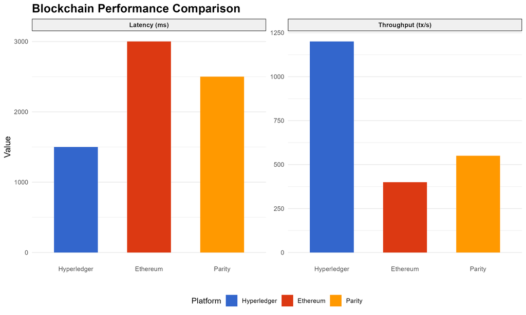

## Bottlenecks Identified

- **Consensus Layer**: Limited throughput, high latency
- **Data Model**: Inefficient data access patterns
- **Execution Engine**: Interpreter overhead, limited optimization
- **Networking**: Communication overhead between nodes

## Lessons & Recommendations

Current blockchain platforms are still immature for enterprise usage

- Need more **optimized data models**
- **Sharding** for improved scalability
- Better **execution engines** for smart contracts
- More efficient **consensus protocols**

## Conclusions

- First systematic framework for evaluating private blockchains
- Significant performance gaps compared to traditional databases
- Major bottlenecks identified across all platforms
- Roadmap for future blockchain optimization

## References

- Dinh, T. T. A., Wang, J., Chen, G., Liu, R., Ooi, B. C., & Tan, K. L. (2017). BLOCKBENCH: A Framework for Analyzing Private Blockchains. Proceedings of the 2017 ACM International Conference on Management of Data.
- [GitHub Repository](https://github.com/ooibc88/blockbench)

## Thank You

Questions?

[figure not shown]

Presentation available at: blockbench-presentation.onrender.com

Financial Software Engineering (ECO5040S) - Assignment 1